# Graphing Choice by Delay Unit

Shelby Leverett

4/16/2020

## *Proportion of Sooner Choice by Unit of Delay & Kval*

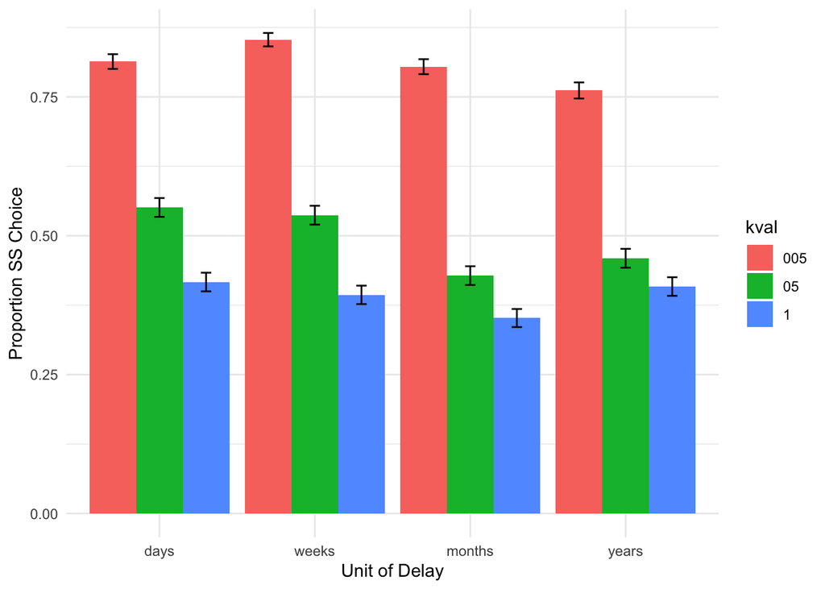

Effect

DFn

DFd

F

p

p<.05

ges

2

Age

1

286

7.141974

0.0079622

0.0144260

3

delay_unit

3

858

10.718162

0.0000006

0.0057965

5

kval

2

572

425.966461

0.0000000

0.1713339

4

Age:delay_unit

3

858

3.930474

0.0084145

0.0021335

6

Age:kval

2

572

7.402952

0.0006696

0.0035804

7

delay_unit:kval

6

1716

8.884094

0.0000000

0.0036971

8

Age:delay_unit:kval

6

1716

3.542346

0.0017255

0.0014774

There is main effect of age (which varied between-subjects) with older adults choosing the smaller, sooner option less.

Effect

W

p

p<.05

3

delay_unit

0.2899775

0

4

Age:delay_unit

0.2899775

0

5

kval

0.6029457

0

6

Age:kval

0.6029457

0

7

delay_unit:kval

0.4252168

0

8

Age:delay_unit:kval

0.4252168

0

Mauchley’s test was significant for all within-subject variable, so use the GGe corrected values below:

Effect

GGe

p[GG]

p[GG]<.05

HFe

p[HF]

p[HF]<.05

3

delay_unit

0.5558641

0.0000943

0.5587345

0.0000913

4

Age:delay_unit

0.5558641

0.0270310

0.5587345

0.0268266

5

kval

0.7157918

0.0000000

0.7183940

0.0000000

6

Age:kval

0.7157918

0.0025144

0.7183940

0.0024839

7

delay_unit:kval

0.7362978

0.0000001

0.7492807

0.0000001

8

Age:delay_unit:kval

0.7362978

0.0052086

0.7492807

0.0049304

## *Proportion of Sooner Options by Delay Unit, Kval, and Age*

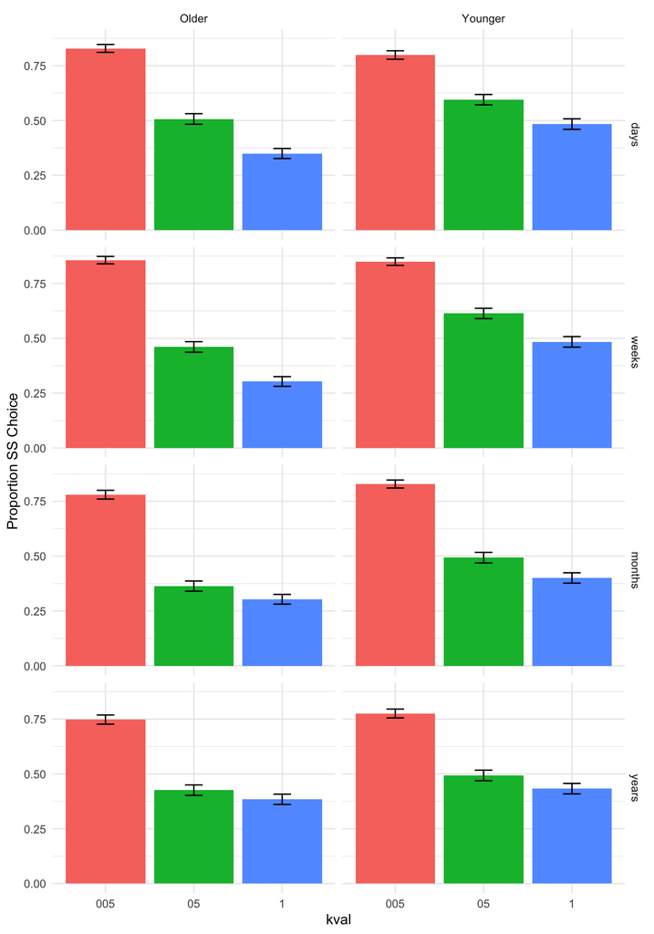